# 1. Installations

## Abdullah Karasan

This is the very first scenario of the Python For Finance series. Throughout these scenarios, Python will be our programming language. You may be wondering why we choose to use Python. Obviously, we have some solid reasons to go for Python. Here are some of them:

- It is simple, intuitive, and allows for customization
- Handling and manipulating large data is an easy task
- It has a rich ecosystem of libraries and tools for finance

Thanks to these advantages, Python has been gaining popularity over a decade. In 2018, `TIOBE`, a software quality company, has declared that Python ranked first in the hall of fame list of programming language. Now, we are about to take advantage of it, too.

In this very first lesson, we will cover the following topics:

- Installations
- Introduction to Jupyter Notebook and Google Colab
- Introduction to required libraries:

  ```
    * Pandas
    * Numpy
    * Scipy
    * Matplotlib
    * Seaborn
  ```

Let's start installing Python. Depending on the operating system we have, there are different ways to install Python. As always, it is better to have newest version of the Python, which is 3.8.

At the time this course is prepared, Python v.3.8 is the newest version, so we are going to install it. If we have Linux operation system, then no worries! Linux distribution comes with Python. We should be able to invoke it with the command `python 3`.

## 1.1. Installing Python 3 on macOS

There are several ways to install Python on Mac. The first option is using `Homebrew`, which is unofficial package manager of macOS. `Homebrew` brings many advantages along with it. So, having it makes life easier for macOS users.

First, check if `Homebrew` is installed:

```
brew
```

If we have an output as “`-bash: brew: command not found`,” it unfortunately means that `Homebrew` is not installed. Otherwise, it would be ready to use. Just make sure that we are using the newest version and run the following command:

```
brew update
```

For those who do not have `Homebrew`, we need to have `XCode Command Line Tools` so that we can smoothly install the `Homebrew` and Python. If we do not have `XCode Command Line Tools`, please go to the `XCode` website and download and install XCode.

Lastly, we can install `XCode Command Line Tools` by running the following command in our terminal:

```
xcode-select --install
```

By installing the `XCode Command Line Tools`, we are ready to install `Homebrew`. Now, please paste the below given one line code in the folder named `brew.sh` and click "Enter":

/usr/bin/ruby -e "$(curl -fsSL \ https://raw.githubusercontent.com/Homebrew/install/master/install)"

Now, confirm that if the installation work. The following command does it for us:

```
brew update
```

If everything is up and running, we are ready to move forward and install Python3 via this command:

```
brew install python3
```

This command installs Python3 and allows interactive Python interpreter to run the python3 command.

It is time to confirm that installation is done in a perfect way:

```
python3 --version
```

If we properly install the Python, this command will return the latest version of Python. If so, congrats!!!

## Alternatively

There is much easier way to install Python along with the necessary libraries, which is called `Anaconda`. As we said, this option provides various advantages despite the fact that it is not top choice of professional data scientists.

Steps to be taken to install Anaconda:

- Visit this page to download Anaconda

[figure not shown]

After visiting the website, go to “Products” and select “Individual Edition” from the top-down menu

[figure not shown]

At the bottom of the page, we will see the `Anaconda Installer`, which includes Windows, Mac, and Linux options. Preferably, select latest version, which is Python 3.7 and downloading automatically starts. The next step is to install Anaconda, which is quite large and therefore may take some time to install.

[figure not shown]

Once we install and start `Anaconda`, we will see the following:

[figure not shown]

What we see is `Anaconda Prompt` and, as we can notice, we have more than one option to run Python. These options are:

- Jupyter Lab
- Jupyter Notebook
- Spyder
- PyCharm

Throughout this course, we will use Jupyter Notebook, which runs on our browser. So, once we click on the `Launch` button under the Jupyter Notebook, a new sheet is created and this is exactly where we start typing our Python scripts.

## 1.2. Installing Python 3 on a Windows OS

If we have a Windows operating system, then the first option is to visit [this page](https://www.python.org/downloads/windows/) so that we can directly download Python 3. Again it is advised to download the latest version of Python. Once we visit the website we will see the following:

[figure not shown]

There are some points we need to consider during the installation process:

- Make sure we select the box `add Python to my path` during the installation.
- Find a shell to work with. Depending on the version of our operating system, it is likely that we have `PowerShell` installed. If PowerShell is installed, check which version we have. If we need it, go to PowerShell GitHub repository, download and install the latest version. But probably the current version will suffice.

## Alternatively

Alternatively, we can load Anaconda. As we have described above in the `Mac section`, this would be a good option for a start. Anaconda contains almost all the packages we would need. So, go directly to Anaconda's website and install Anaconda on our computer.

## 1.3. Jupyter Notebook

Jupyter Notebook allows us to write, run, and visualize Python interactively. Having both code and text elements in Jupyter makes it an ideal (and one of the most widely used) IDE for Python. Because, we can both script the code and write down the descriptions to present them. Besides, we can execute analysis in real time. In this course, we recommend using Jupyter notebooks as IDE to write Python scripts. Once we create a new Jupyter Notebook, this is what we have:

[figure not shown]

At this point, let's talk about some components of Jupyter Notebook so that it makes our transition to Jupyter Notebook painless and fast. `Cells` and `Markdown` are two topics that we are about to touch.

### 1.3.1. Cells

Jupter Notebook works via `cells`, which contains everything we put in the Notebook. Right now, we are working in a cell. Nothing happens when we type something inside the cell, we need to run it, and in order to run it we need to click on the `run` button at the top of the Notebook. Alternatively, after selecting the cell `ctrl + Enter` can be used, too.

A notebook can have as many cells as we need. There are several ways to add cells. When we run the last cell in the notebook, a new cell is automatically added. Also, if we have a selected but inactive cell, whose color is blue, we can press `a` if we want to add a cell above that cell, or `b` if we want to add a cell below it. To delete a cell, press `x`.

Each notebook runs in a Python environment. Codes are run in an orderly way. That is to say, the output of the preceding code will be the input of the subsequent one. If we do not pay attention to the ordering of the codes in the cells, we may encounter some coding issues. If we change the code in our cell or run it multiple times, we may have changed the variables or output in an undesired way. The same thing can also happen if we run cells in the wrong order. That's why it is very important that all our code is sequential and executable!

We can start typing our code inside the cell, which is surronded by green frame. As default, Jupyter notebook uses `Code`, which allows we to type our code in the cell.

[figure not shown]

Please note that the drop down menu indicated by the red arrow allows us to type either the code or write down text, along with other options such as a heading. If we click on this drop down menu, we are going to see 4 options, which are:

- Code
- Markdown
- Raw NB Convert
- Heading

### 1.3.2. Markdown

So far we have only talked about code cells, but there are other types of cells. One of the important cell types we need to know is the markdown cell. This cell is actually a marking cell. We can double-click the markdown cell and edit it. We can see what the output looks like by running the cell.

When we want to use a Jupyter Notebook to write a report, we may want to write notes that would not be convenient using comments in the Python code (comments that begin with the # sign and do not affect the code). Markdown cells can be used for this purpose. By default, each new cell is a code cell. To convert a cell into a markdown cell, select the cell, make sure it is inactive and press m. It's that simple. Or, as shown before, go to drop down menu and select `Markdown`.

Before diving into the coding, I strongly suggest you to visit [this page](https://jupyter-notebook.readthedocs.io/en/stable/) and take a look.

In the last part of the first section, I would like to introduce another platform in which you can run your own analysis: `Google Colaboratory`.

## 1.4. Google Colaboratory

Colab is a free platform for running Jupyter Notebooks in the cloud. Before getting started, it is better for us to know that Python and all its major data analysis libraries are already installed. So, we do not need to install anything. So, we can just upload our Jupyter Notebooks and run them on Colab without any modifications to our code.

### 1.4.1 Create An Account

If we're using Gmail or any other services of Google, then we have a Google account. But if we don't already have a Google account, then we need to create one for ourself. We can do this here. Creating an account is the first step and [this](https://accounts.google.com/signup/v2/webcreateaccount?flowName=GlifWebSignIn&flowEntry=SignUp) link will help us do that.

## 1.4.2. Setting Up a Colab on Google Drive

Now, we are trying to connect Google Colaboratory, `Google Colab` for short, with Google Drive. To do that, first visit our Google account and click on the `Drive` image at the top right corner of the screen:

[figure not shown]

By clicking on the Drive image, we access our `Google Drive` in a new tab on our browser. Google Drive allows us to upload files. Now, let's connect Google Colab to Google Drive. All we need to do is to click on the `+ New` button at the top left corner of our drive once we entered to our drive:

[figure not shown]

After clicking the `+ New` button on the left corner of our drive, go down and find `More` in which we will find `+ Connect more apps`:

[figure not shown]

Once we click on the `+ Connect more apps`, type `colab` and search for it. Then, click on the Colaboratory and then click on the `+ Connect` button:

As soon as our installation is completed, a message saying "Colaboratory was connected to Google Drive" will appear, meaning that we successfully connected Colab to our drive.

[figure not shown]

Now, we are ready to go and check to if `Google Colab` is under `More` button on our Google Drive. So, we should have this:

[figure not shown]

Congrats!!! We are good to go. Now, once we click on the `Google Colaboratory`, a new tab will pop up. This is `Google Colab` where we can start coding Python in cloud.

One last thing; If we want to upload our Jupyter Notebook, just visit our Google Drive and find our Jupyter Notebook (of course, we should have one before doing this operation) and double-click on it. We should see the option to open this file with Google Colaboratory.

# 2. Installing the Python Libraries

In this section, we are going to learn how to install the most widely used Python libraries. We will also do some basic operations using these libraries. The aim is to get our hands dirty before diving into financial modeling with Python.

The most frequently used Python libraries are:

- Pandas
- Numpy
- Matplotlib
- Scipy

## 2.1. Pandas

Pandas is an open source library providing fast, flexible, and expressive data structures. It has easy-to-use data structures and data analysis tools. Pandas is particularly suited to the analysis of tabular data, i.e. data with rows and columns.

It is not wrong to say that `Pandas` is the excel counterpart of Microsoft in Python environment. This package is the basic data manipulation library in the Python ecosystem. This library offers us special objects such as `data frame` that we will consistently use as long as we script in Python.

It is easy to install Pandas via Shell or Terminal by this command:

```python
pip3 install pandas
```

If we have Python 3.x, we use `pip3` command to install the libraries. Once we are done with the installation, `pip3 freeze` helps us to check our installation. This is one-time application until we need an upgrade. Now, let's continue coding in Jupyter Notebook after installing the Pandas. Everytime we open a new Jupyter Notebook, we need to import the libraries that have already installed. The following code import Pandas and abbreviate it as `pd` meaning that we do not type Pandas anymore but type shorter version of it, which is `pd`.

```python
import pandas as pd
```

We can generate our own data and store it in data frame in Pandas. But now, let's start with importing data from external source. Given that we have data in our local computer and want to import it in Python. Here is what we should do if we have data with `csv` extension:

```python
df=pd.read_csv('datasets/diabetes.csv')
```

Now, the name of the data is `df` as written on the left hand side of the equation. It is arbitrarily assigned, we can change the name of the data with our choice. As you may notice, in order to import our data, we type `read_csv` and, depending on the data extension we have, this code changes. Please refer to this for other extensions.

So, now the question is how do we know that the data has a data frame format. It is easy because we use `pd`, as long as we use `pd`, data frame is what we have. The other question would be what does the data frame look like? As we have mentioned above it is the Excel of Python. To recap, it has tabular format as we see below:

```python
df.head()
```

|  | Pregnancies | Glucose | BloodPressure | SkinThickness | Insulin | BMI | DiabetesPedigreeFunction | Age | Outcome |
| --- | --- | --- | --- | --- | --- | --- | --- | --- | --- |
| 0 | 6 | 148 | 72 | 35 | 0 | 33.6 | 0.627 | 50 | 1 |
| 1 | 1 | 85 | 66 | 29 | 0 | 26.6 | 0.351 | 31 | 0 |
| 2 | 8 | 183 | 64 | 0 | 0 | 23.3 | 0.672 | 32 | 1 |
| 3 | 1 | 89 | 66 | 23 | 94 | 28.1 | 0.167 | 21 | 0 |
| 4 | 0 | 137 | 40 | 35 | 168 | 43.1 | 2.288 | 33 | 1 |

`.head()` function allows us to observe the dataset. Now, we can see the columns and first five rows. Of course, there is much more than that and if you want to learn more about `.head()` function, please visit this website.

Let's now create our own data frame with our own dataset.

```python
df = pd.DataFrame({'City' : ['New York', 'London', 'Paris', 'istanbul'],
                   'Population (million)':  [8399, 8982, 2143, 1552],
                  })
df
```

|  | City | Population (million) |
| --- | --- | --- |
| 0 | New York | 8399 |
| 1 | London | 8982 |
| 2 | Paris | 2143 |
| 3 | istanbul | 1552 |

Thus far, we've only talked about data frames, but what happens if we work with one-dimensional data? The answer is `Series`. It is a one-dimensional object that can store integers, floats, and strings. The code below shows how to create a `Series`:

```python
data = pd.Series([15,'hello',25,'apple','23.3'])
data
```

```
0       15
1    hello
2       25
3    apple
4     23.3
dtype: object
```

## 2.2. NumPy

Generally speaking, NumPy is a linear algebra library, which allows us to apply any algebraic operations. However, it is not the only function it has in Python ecosystem. Rather, we are talking about frequently used data type in data science applications.

To start with, we need to install numpy. Please note that depending on our Python installation, numpy may be installed already. If not, type the following command:

```python
pip3 install numpy
```

As we did in Pandas, after installing the NumPy library, it is time to import it via the following code:

```python
import numpy as np
```

By convention `np` is used to represent NumPy. Now, we are ready to dig into NumPy. As we mentioned above, NumPy is a basic package for storing and modifying mathematical data in Python. NumPy does this with a new data structure called `array`.

One of the main advantages of the array is the multidimensionality property. Simply by typing `np.array()`, we can create a list.

```python
multi = np.array([[0, 1, 2, 3],[4, 5, 6, 7]])
multi
```

```
array([[0, 1, 2, 3],
       [4, 5, 6, 7]])
```

It is very important to know the size of the arrays. Because the dimensions must be compatible with each other. We can learn the size of an array with the `.shape()` method. `.shape` function tells us that we have 2 rows and 4 columns:

```python
print(multi.shape)
```

```
(2, 4)
```

It is also possible to make some changes in the array. Let's assign different the elements in an array starting from the second index:

```python
array = np.array([0, 1, 2, 3])
array[2:] = [5,4]
print(array)
```

```
[0 1 5 4]
```

As we mentioned, there are many operations we can do with array. `append` is just one of them. It basically add new elements to the array.

```python
np.append(array, (7,8,9))
```

```
array([0, 1, 5, 4, 7, 8, 9])
```

Finally, I would like to talk about basic mathematical operations that we can do in numpy. These operations include summation, multiplication, division, element-wise operations, and aggregator function. Let's first start with summation, multiplication, and division.

```python
array1 = np.array([0, 1, 2, 3])
array2 = np.array([2, 4, 6, 8])
print (array1 + array2)
```

```
[ 2  5  8 11]
```

```python
array1 = np.array([[0, 1, 2, 3],[4, 5, 6, 7]])

print(array2 = array1*2)

print(array2)
```

[output not shown]

```python
print(array1/array2)
```

[output not shown]

Thus, the application of basic mathematical operations are easy-to-apply. Now, it is time to do some element-wise operations. Among others, these operations include taking the square and square root. To do that we will use `.square()`and `.sqrt()` functions.

```python
x = np.array(np.arange(5))
np.square(x)
```

```
array([ 0,  1,  4,  9, 16])
```

```python
np.sqrt(x)
```

```
array([0.        , 1.        , 1.41421356, 1.73205081, 2.        ])
```

As a final step, we will look at aggregator functions in NumPy. Finding minimum, maximum, mean values, and standard deviation are some examples of aggregator functions.

```python
age=np.array([18, 25, 22, 34, 26, 27, 19, 28, 30, 24])
```

```python
print(np.max(age))
print(np.min(age))
print(np.mean(age))
print(np.std(age))
```

```
34
18
25.3
4.627094120503711
```

So, it turns out finding summary statistics about a data is quite easy in NumPy. Those who want to learn more can apply to this [website](https://numpy.org/doc/stable/).

## 2.3. SciPy

SciPy is a relatively specific library for some technical applications such as engineering and scientific studies. It is possible to do optimization, statistical analysis, and linear algebra. The modules that we can take advantage in SciPy are:

- Interpolation
- Integration
- Optimization
- Image processing
- Statistics
- Special functions

In order to install SciPy library, we again refer to pip3 command as follows:

```python
pip3 install scipy
```

**A side note**: If we want to install libraries via Jupyter Notebook, instead of `pip`, just type `!pip`.

Now, let's import this library and practice. For the sake of practice, we will conduct a basic interpolation analysis. The package name for interpolation is `interp1d`, which is used to fill in missing values based on the existing function.

```python
from scipy.interpolate import interp1d
```

First, we define arbitrary x and y values. Then, using `interp1d`, we find a way to model the relationship between x and y.

```python
x = np.linspace(0, 1, 100)
y = 1.7 * np.cos(2.3 * x_data) + np.random.normal(size=100)
```

```python
f = interp1d(x, y)
```

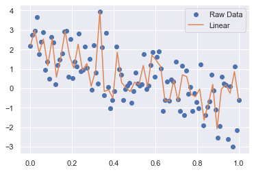

```python
x_new = np.linspace(0, 1, num=49, endpoint=True)
plt.plot(x, y, 'o', x_new, f(x_new), '-')
plt.legend(['Raw Data', 'Linear'])
plt.show()
```

## 2.4. Matplotlib

Visualization is an indispensable part of the data analysis. Before moving forward to modeling, it would be helpful to observe data by visualizing it. Python has more than one tool to serve this purpose and `Matplotlib` library is one of the most preferable ones.

I assume we have gotten used to first-time installation process of the libraries in Python. `Matplotlib` can also be installed by typing:

```python
pip3 install matplotlib
```

Let's import `matplotlib` now, which is similar to how we install the other libraries:

```python
import matplotlib.pyplot as plt
```

```python
df=pd.read_csv('datasets/company_sales_data.csv')
```

```python
df.head()
```

|  | month_number | facecream | facewash | toothpaste | bathingsoap | shampoo | moisturizer | total_units | total_profit |
| --- | --- | --- | --- | --- | --- | --- | --- | --- | --- |
| 0 | 1 | 2500 | 1500 | 5200 | 9200 | 1200 | 1500 | 21100 | 211000 |
| 1 | 2 | 2630 | 1200 | 5100 | 6100 | 2100 | 1200 | 18330 | 183300 |
| 2 | 3 | 2140 | 1340 | 4550 | 9550 | 3550 | 1340 | 22470 | 224700 |
| 3 | 4 | 3400 | 1130 | 5870 | 8870 | 1870 | 1130 | 22270 | 222700 |
| 4 | 5 | 3600 | 1740 | 4560 | 7760 | 1560 | 1740 | 20960 | 209600 |

### 2.4.1. Line Plot

First visualization tool that we see is line plot, which is an important part of the univariate analysis. To do that, `.plot()` function is used. Moreover, if we want to add labels for x and y axes together with plot title, we can do that right after defining the plot type. In the following example, we have a line plot in which `month_number` is locating on the x-axis and `total_profit` is on the y-axis.

Before moving forward, it is worth discussing a point about visualization. It is necessary to call the `plt.show()` function to show the plots in matplotlib. If we are using a Jupyter Notebook, we can use the `%matplotlib inline` command, which is one of the commands in Jupyter Notebooks called a magical command to create the graphics well.

In Jupyter Notebooks, it is always a good practice to include this line in the first cell, once our packages are imported. This statement prevents our images from being always being produced in a notebook instead of popups and a slow matplotlib compilation generates rendering errors.

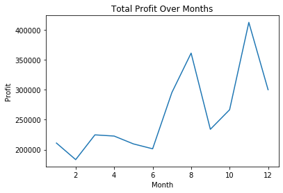

```python
%matplotlib inline
plt.plot(df['month_number'],df['total_profit'])
plt.title('Total Profit Over Months')
plt.xlabel('Month')
plt.ylabel('Profit')
plt.show()
```

### 2.4.2. Scatter Plot

A scatter plot is a tool for bivariate data exploration. The code below shows how we draw a scatter plot. It turns out that there is almost one-to-one relationship between `total_profit` and `total_units`. To draw a scatter plot, all we need to do is to type `.scatter()`.

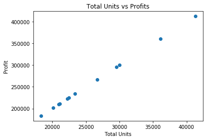

```python
plt.scatter(df.total_units,df.total_profit)
plt.title('Total Units vs Profits')
plt.xlabel('Total Units')
plt.ylabel('Profit')
plt.show()
```

If we want to have more than one scatter plot at once, it is easy. Just apply `.scatter()` function twice with different x and y axes.

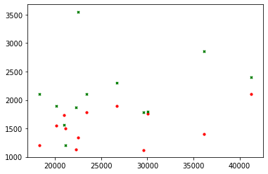

```python
plt.scatter(
    x=df['total_units'],
    y=df['moisturizer'],
    color='red',
    marker='o', s=10
)
plt.scatter(
    x=df['total_units'],
    y=df['shampoo'],
    color='green',
    marker='x', s=10
)
plt.show()
```

### 2.4.3. Histogram

A histogram is a great tool to show the possible values of a variable and how frequent these values are. In addition to that, histogram gives us an initial idea about the distribution of the data has. It may be quite important to know the distribution of a data before running a model because some models assume a certain type of distribution.

The histogram begins by dividing the values into bins. These bins are equal-sized ranges with an upper and lower limit. The histogram then counts how many values are in each bin and draws a bar corresponding to this number for each bin. This gives us an idea of the frequency of the range of its variable. So, histograms are great for visualizing the distribution of a variable.

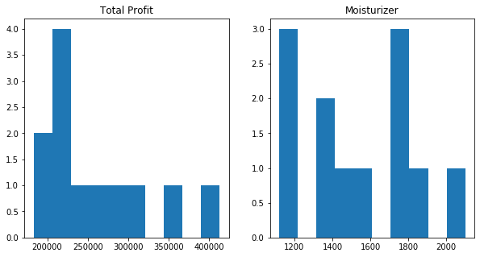

```python
plt.figure(figsize=(10, 5))

plt.subplot(1, 2, 1)
plt.hist(df.total_profit)
plt.title('Total Profit')
plt.subplot(1, 2, 2)
plt.hist(df.moisturizer)
plt.title('Moisturizer')

plt.show()
```

Histogram of the total profit shows that many of the values in total profit gather between 200,000 and 250,000. However, we have two peaks in terms of frequency in moisturizer. The first one occurs when moisturizer takes on values around 1,200 and the other happens when it takes on values around 1,800.

### 2.4.4 Box Plot

Another useful visualization is the boxplot. We can create a boxplot with the `.boxplot()` function. A boxplot is a relatively simple visualization. Let's create one and then examine its properties.

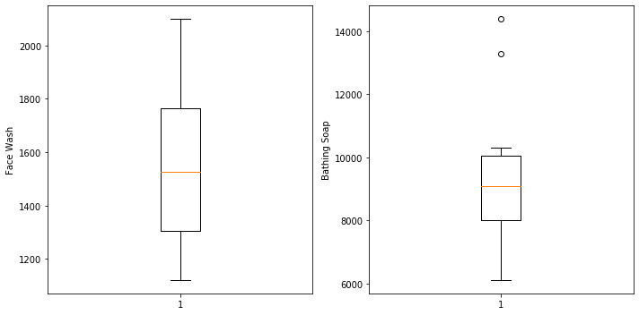

```python
plt.figure(figsize=(10, 5))

plt.subplot(1, 2, 1)
plt.boxplot(df.facewash)
plt.ylabel('Face Wash')

plt.subplot(1, 2, 2)
plt.boxplot(df.bathingsoap)
plt.ylabel('Bathing Soap')

plt.tight_layout()
plt.show()
```

The boxplot consists of a box containing what is called `quartile` (interquartile range or IQR for short). First of all, let's explain what the quartile means. We can divide a variable into four quartiles based on the values it contains:

- From the lowest value to 25%
- From 25% to the median
- From the median to 75%
- From 75% to the maximum value

Boxplots are not useful for learning about the distribution of a variable. However, it is very useful for eyeballing the range of values and for detecting possible `outliers`. Data points marked with a dot or circle on a box diagram are generally considered to be outliers. Therefore, boxplots are widely used when working on new data. For more information about boxplots, see the `.boxplot()` [documentation](http://matplotlib.org/api/pyplot_api.html#matplotlib.pyplot.boxplot).

## 2.5. Seaborn

`Seaborn` is another tool for visualization in Python. This package allows us to have some fancy visualizations simply by typing a few lines of code. We can think of it as a more advanced tool for visualization.

Again, we install seaborn package via:

```python
pip3 install seaborn
```

After installing the package, let's import it. But if we want to use the style of seaborn, which is cooler than that of matplotlib, we need to type `sns.set()`

```python
import seaborn as sns; sns.set()
```

### 2.5.1. Line Plot

In this part, we will draw a line plot. We have `total_profit` and `month_number` on the y and x axes, respectively.

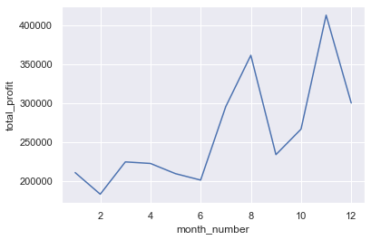

```python
sns.lineplot(x="month_number", y="total_profit", data=df)
```

As we see, it looks different than what we have in matplotlib in terms of background, font, etc.

### 2.5.2. Scatter Plot

It is easy to have scatter plot and of course the logic is the same as matplotlib, but we see a different style compared to matplotlib.

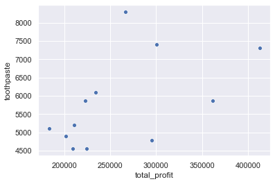

```python
sns.scatterplot(x='total_profit',y='toothpaste',data=df)
```

We can obtain scatter plot with `.Implot()`, which is intended to fit regression model. The result is given below, the line we see in this plot is called `fit line`.

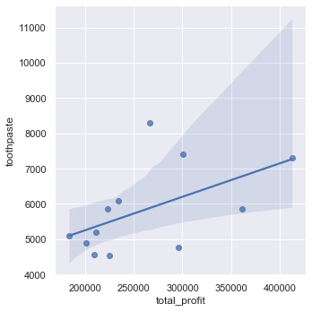

```python
sns.lmplot(x='total_profit',y='toothpaste',data=df)
```

### 2.5.3. Box Plot

```python
pokemon=pd.read_csv('datasets/Pokemon.csv')
```

```python
pokemon.head()
```

|  | # | Name | Type 1 | Type 2 | Total | HP | Attack | Defense | Sp. Atk | Sp. Def | Speed | Generation | Legendary |
| --- | --- | --- | --- | --- | --- | --- | --- | --- | --- | --- | --- | --- | --- |
| 0 | 1 | Bulbasaur | Grass | Poison | 318 | 45 | 49 | 49 | 65 | 65 | 45 | 1 | False |
| 1 | 2 | Ivysaur | Grass | Poison | 405 | 60 | 62 | 63 | 80 | 80 | 60 | 1 | False |
| 2 | 3 | Venusaur | Grass | Poison | 525 | 80 | 82 | 83 | 100 | 100 | 80 | 1 | False |
| 3 | 3 | VenusaurMega Venusaur | Grass | Poison | 625 | 80 | 100 | 123 | 122 | 120 | 80 | 1 | False |
| 4 | 4 | Charmander | Fire | NaN | 309 | 39 | 52 | 43 | 60 | 50 | 65 | 1 | False |

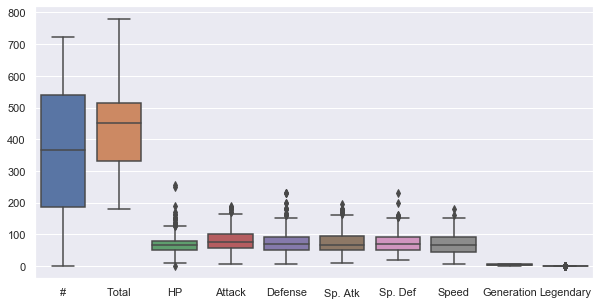

```python
plt.figure(figsize=(10, 5))
sns.boxplot(data=pokemon)
```

However, seaborn has more than these plot. As we discuss at the very beginning of the part, seaborn provides us some fancy tools. These tools include `violin plot` and `histogram`. Before wrapping up, let's briefly talk about them.

### 2.5.4. Violin Plot

The violin chart is an alternative to the box plot and it exhibits distribution of a data in a different way.

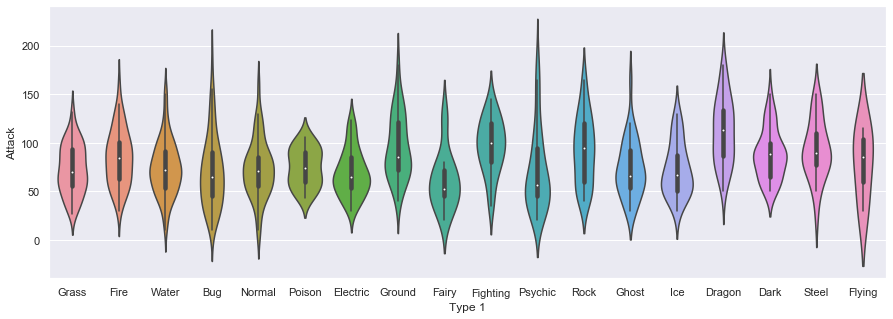

```python
plt.figure(figsize=(15, 5))
sns.violinplot(x='Type 1',y='Attack',data=pokemon)
```

### 2.5.5. Histogram

In seaborn package, we use different function to call histogram, which is `.distplot()`. This techniques does exactly what we have done in matplotlib but again with different style.

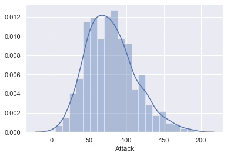

```python
sns.distplot(pokemon.Attack)
```

Would you like to learn more? I suggest you to refer this [website](https://seaborn.pydata.org), which includes all visualization techniques that seaborn library has.

The next notebook you should read in this series is Financial Data Sources and APIs.